# Audience Ratios of the Theater Plays by Stage

Shining Stars

17 12 2021

# Project Description

### Project Goal

Visualizing the relationship between the Stage’s properties such as location, longitude etc. and the number of audience of the play which is staged.

## Data Description

In this data, information showing the type, category, the theater in which they were played, that is, in which district they were played, were recorded in the city theaters of Istanbul Metropolitan Municipality. Using these data, it can be examined whether the welfare levels of some districts in Istanbul are higher in terms of following and accessing cultural activities than others. Within the scope of this project, it can be observed whether there is a relationship between the location of the plays played and the type of games played too.Data on the theater plays played were taken from the Istanbul Metropolitan Municipality Open Data Portal.

## Access to data:

Data is available on the website of Istanbul Büyükşehir Belediyesi Open Data Portal as XML, CSV, JSON and TSV files.

[To access data](https://data.ibb.gov.tr/en/dataset/sehir-tiyatrolari-veri-seti/resource/79465ce9-8755-4b57-8e6c-def0c0caadc8)

## Variables

- Date
- Name
- Theater Name
- Category
- Is Guest
- Type
- Longitude
- Latitude
- Number of Audience

```
## # A tibble: 78 x 2
##    THEATER_NAME                            SUM_AUDIENCE
##    <chr>                                          <int>
##  1 ""                                                 4
##  2 "  AYSA TİYATROSU"                               215
##  3 "  MİMBAZ TİYATRO"                                89
##  4 " ALTIDAN SONRA TİYATRO"                         123
##  5 " ALTKAT SANAT"                                  124
##  6 " ANKARA BİRLİK TİYATROSU"                        90
##  7 " AYSA TİYATRO"                                  152
##  8 " AYSA TİYATROSU"                                279
##  9 " BODRUM DENEME SAHNESİ"                         137
## 10 " BOĞAZİÇİ GÖSTERİ SANATLARI TOPLULUĞU"           94
## # ... with 68 more rows
```

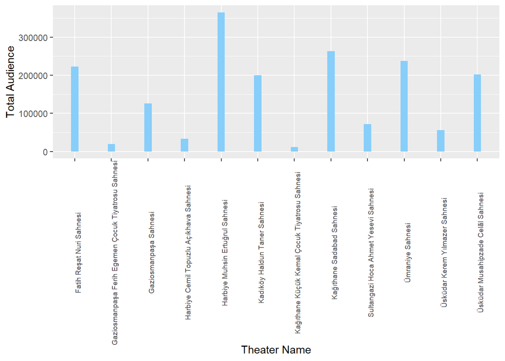

```
##        district population sum_audience_by_districts audience_ratio
## 1     Kağıthane     442415                      4038    0.009127177
## 2         Fatih     396594                      3364    0.008482226
## 3 Gaziosmanpaşa     487778                      3927    0.008050794
## 4      Ümraniye     713803                      3260    0.004567086
## 5         Şişli     266793                      3382    0.012676495
## 6       Üsküdar     520771                      4497    0.008635273
## 7       Kadıköy     481983                      2528    0.005244998
## 8    Sultangazi     537488                      1690    0.003144256
```

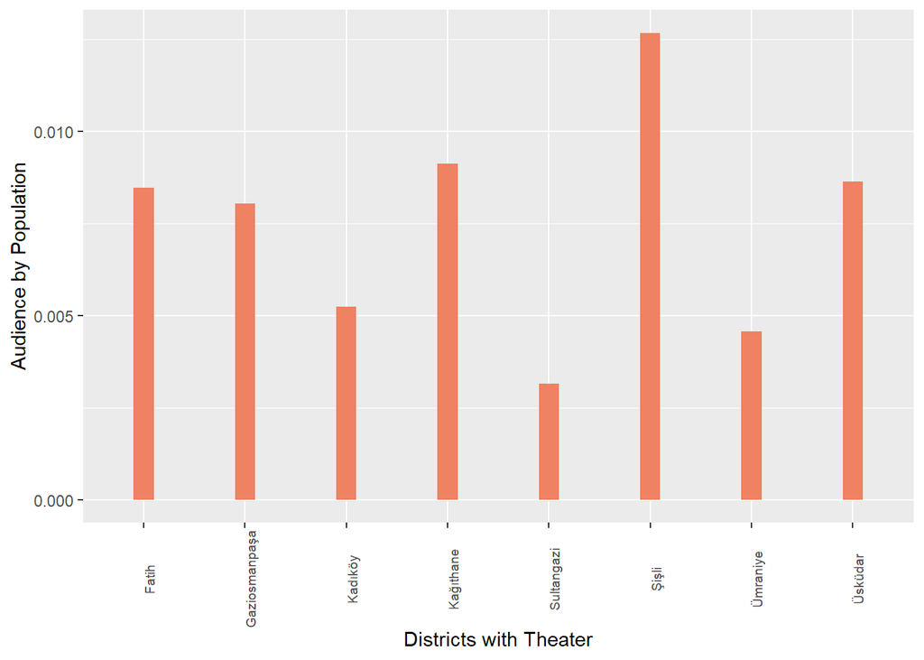

```
##        district population undergraduate_or_higher education_ratio
## 1     Kağıthane     442415                   70086      0.15841687
## 2         Fatih     396594                   59627      0.15034771
## 3 Gaziosmanpaşa     487778                   56793      0.11643207
## 4      Ümraniye     713803                  134935      0.18903675
## 5         Şişli     266793                   72257      0.27083544
## 6       Üsküdar     520771                  142231      0.27311621
## 7       Kadıköy     481983                  209465      0.43459002
## 8    Sultangazi     537488                   38979      0.07252069
```

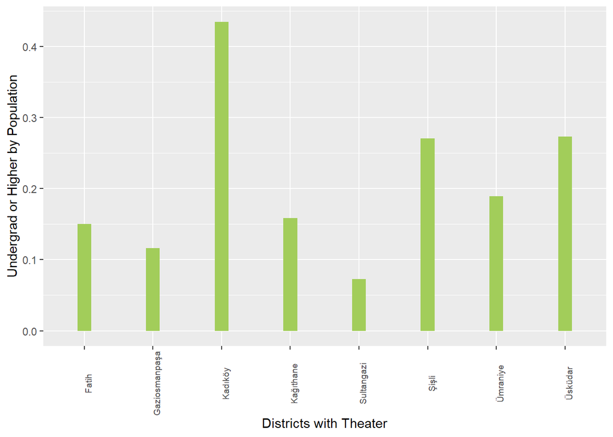

# Results and Discussion

When we started our project, we wanted to examine the relationship between the viewing rates of theater plays and their location. For this, we evaluated values such as ease of transportation and proximity to the center based on our own information, not on any data. However, as seen in the interim report, we did not find a direct effect of location. Then we drew new graphs using parameters such as the population and education level of the district. Although these are more successful than the location, they are still not sufficient as a single parameter.

Since we could not find any data on the income level, we can only guess from graphs and tables. However, we see that the increasing population rate can affect the viewing rate. There is no direct effect of the education level of the district. The fact that Istanbul is a polycentric district and the population is quite scattered also has an effect on this. Therefore, it becomes very difficult to come to a conclusion with simple parameters. In a more detailed project, new parameters can also be included and an expert can be worked with.

# Conclusion

In conclusion, when working on such a project, it would be much more useful to use multiple parameters and examine their relationship to each other. While some projects do not require much data, in such projects more data may mean more analysis. Since the project will also include sociological and demographic analysis, getting help from an expert can make the project more successful. Because it is very difficult for two university students to choose the parameters they will use while deciding on the demographic structure of Istanbul.

# References

- https://data.ibb.gov.tr/dataset/sehir-tiyatrolari-veri-seti/resource/79465ce9-8755-4b57-8e6c-def0c0caadc8
- http://www.sthda.com/english/wiki/ggplot2-title-main-axis-and-legend-titles
- https://www.data-to-viz.com/
- https://www.endeksa.com/tr/analiz/istanbul/demografi